# Trabajo final

Federico Acosta y Lara

1/28/2021

1. **¿Cuál fue el resultado de la elección en porcentaje a nivel nacional?**

El resultado de la elección a nivel nacional por partido político se puede ver en la siguiente tabla.

Como se puede ver, el partido que obtuvo más votos a nivel nacional fue el Partido Frente Amplio, obteniendo el 40.56% de los votos, que implica una diferencia de 10.81% con el partido que salió en segundo lugar (el Partido Nacional)

| Partido | Votos | % del total |
| --- | --- | --- |
| Partido Frente Amplio | 927741 | 40.56 |
| Partido Nacional | 680420 | 29.75 |
| Partido Colorado | 292694 | 12.80 |
| Partido Cabildo Abierto | 259929 | 11.36 |
| Partido Ecologista Radical Intransigente | 32577 | 1.42 |
| Partido Independiente | 22243 | 0.97 |
| Partido de la Gente | 26036 | 1.14 |
| Partido Asamblea Popular | 19084 | 0.83 |
| Partido Verde Animalista | 18881 | 0.83 |
| Partido Digital | 6280 | 0.27 |
| Partido de los Trabajadores | 1358 | 0.06 |

Fuente: Elaboración propia en base a datos de la Corte Electoral

2. **¿Quién ganó la elección en cada departamento y cuál fue la distancia en términos porcentuales entre el primero y el segundo en cada departamento?**

La Tabla 2 resume el ganador por departamento y el margen de victoria.

Partido ganador por departamento y margen de victoria. Elección Nacional. Uruguay Octubre 2019

| Departamento | Partido Ganador | Margen (%) |
| --- | --- | --- |
| Artigas | Partido Nacional | 16.61 |
| Canelones | Partido Frente Amplio | 15.97 |
| Cerro Largo | Partido Nacional | 9.54 |
| Colonia | Partido Frente Amplio | 1.34 |
| Durazno | Partido Nacional | 7.25 |
| Flores | Partido Nacional | 9.91 |
| Florida | Partido Nacional | 3.01 |
| Lavalleja | Partido Nacional | 12.42 |
| Maldonado | Partido Nacional | 8.22 |
| Montevideo | Partido Frente Amplio | 24.98 |
| Paysandu | Partido Frente Amplio | 4.83 |
| Rio Negro | Partido Frente Amplio | 1.41 |
| Rivera | Partido Colorado | 1.1 |
| Rocha | Partido Frente Amplio | 2.58 |
| Salto | Partido Frente Amplio | 12.81 |
| San Jose | Partido Frente Amplio | 3.71 |
| Soriano | Partido Frente Amplio | 3.93 |
| Tacuarembo | Partido Nacional | 7.03 |
| Treinta y Tres | Partido Nacional | 12.06 |

Fuente: Elaboración propia en base a datos de la Corte Electoral

Puede verse que el Partido Nacional fue victorioso en 9 de los 19 departamentos, el Frente Amplio lo fue en 9, mientras que el Partido Colorado en 1.

Por otra parte, la mayor diferencia a favor la obtuvo el Partido Frente Amplio, con el 24.98% de ventaja en el departamento de Montevideo , mientras que el margen más acotado se dio en Rivera donde el Partido Colorado se impuso con tan solo el 1.1% de los votos.

3. **¿Cuál fue la hoja de votación más votada en cada departamento y para cada uno de los tres partidos principales del sistema?**

La respuesta es presentada en la tabla siguiente.

Hoja más votada por departamento y por partido. Elección nacional. Uruguay Octubre 2019

| DEPTO | LEMA | HOJA | CNT_VOTOS |
| --- | --- | --- | --- |
| Artigas | Partido Colorado | 600 | 1311 |
|  | Partido Frente Amplio | 90609 | 3029 |
|  | Partido Nacional | 2525 | 14639 |
| Canelones | Partido Colorado | 600 | 16690 |
|  | Partido Frente Amplio | 609 | 57182 |
|  | Partido Nacional | 400 | 40295 |
| Cerro Largo | Partido Colorado | 600 | 2728 |
|  | Partido Frente Amplio | 609 | 4935 |
|  | Partido Nacional | 3 | 15040 |
| Colonia | Partido Colorado | 600 | 8125 |
|  | Partido Frente Amplio | 609 | 8994 |
|  | Partido Nacional | 904 | 12006 |
| Durazno | Partido Colorado | 600 | 2915 |
|  | Partido Frente Amplio | 609 | 4602 |
|  | Partido Nacional | 404 | 8071 |
| Flores | Partido Colorado | 600 | 1771 |
|  | Partido Frente Amplio | 1810 | 1473 |
|  | Partido Nacional | 404 | 3897 |
| Florida | Partido Colorado | 600 | 4210 |
|  | Partido Frente Amplio | 609 | 4519 |
|  | Partido Nacional | 62 | 10692 |
| Lavalleja | Partido Colorado | 600 | 3658 |
|  | Partido Frente Amplio | 90609 | 3226 |
|  | Partido Nacional | 5859 | 8430 |
| Maldonado | Partido Colorado | 2600 | 7096 |
|  | Partido Frente Amplio | 609 | 7202 |
|  | Partido Nacional | 22 | 17203 |
| Montevideo | Partido Colorado | 600 | 55896 |
|  | Partido Frente Amplio | 609 | 135259 |
|  | Partido Nacional | 404 | 57932 |
| Paysandu | Partido Colorado | 600 | 5602 |
|  | Partido Frente Amplio | 609 | 10689 |
|  | Partido Nacional | 51 | 12698 |
| Rio Negro | Partido Colorado | 600 | 4134 |
|  | Partido Frente Amplio | 212199808 | 3134 |
|  | Partido Nacional | 58 | 6480 |
| Rivera | Partido Colorado | 2000 | 12754 |
|  | Partido Frente Amplio | 711609 | 3052 |
|  | Partido Nacional | 15 | 8884 |
| Rocha | Partido Colorado | 600 | 2905 |
|  | Partido Frente Amplio | 609 | 6042 |
|  | Partido Nacional | 404 | 7163 |
| Salto | Partido Colorado | 20115 | 5871 |
|  | Partido Frente Amplio | 1786 | 11616 |
|  | Partido Nacional | 404 | 10989 |
| San Jose | Partido Colorado | 600 | 4448 |
|  | Partido Frente Amplio | 609 | 9236 |
|  | Partido Nacional | 404 | 13019 |
| Soriano | Partido Colorado | 600 | 5404 |
|  | Partido Frente Amplio | 90609 | 7859 |
|  | Partido Nacional | 903 | 10681 |
| Tacuarembo | Partido Colorado | 600 | 4604 |
|  | Partido Frente Amplio | 609 | 5749 |
|  | Partido Nacional | 71404 | 10983 |
| Treinta y Tres | Partido Colorado | 600 | 1568 |
|  | Partido Frente Amplio | 402121 | 3303 |
|  | Partido Nacional | 8 | 6727 |

Fuente: Elaboración propia en base a datos de la Corte Electoral

Es de notar que en el caso del Frente Amplio, la hoja ganadora en más departamentos fue la 609 que ganó en 11 departamentos. En el caso del Partido Nacional, lo fue la hoja 404 con 6 departamentos a su favor, mientras que la hoja colorada más victoriosa con 16 departamentos fue la 600.

4. **¿En qué departamento votó mejor el partido Cabildo Abierto?**

El departamento en el que Cabildo Abierto obtuvo su mejor votación (como porcentaje del total de votos del departamento) fue Rivera, con un 24.59%.

5. **¿Cuál es la distribución de edad en los circuitos de todo el país en donde ganó o salió segundo Cabildo Abierto?**

La tabla inferior muestra los principales estadísticos de resumen de la distribución de edad en los circuitos en los que Cabildo Abierto salió primero o segundo.

Estadísticos de resumen. Edad promedio de los circuitos dónde Cabildo Abierto fue exitoso.

| Estadístico | Valor Cabildo Abierto | Valor general |
| --- | --- | --- |
| Mínimo | 24 | 22 |
| Media | 45.75 | 47.23 |
| Mediana | 45 | 45 |
| Máximo | 81 | 91 |
| D.Estandar | 12.53 | 14.16 |
| N | 462 | 7113 |

Fuente: Elaboración propia en base a datos de la Corte Electoral

6. **Presente los resultados de la pregunta 1 y 2 gráficamente.**

[figure not shown]

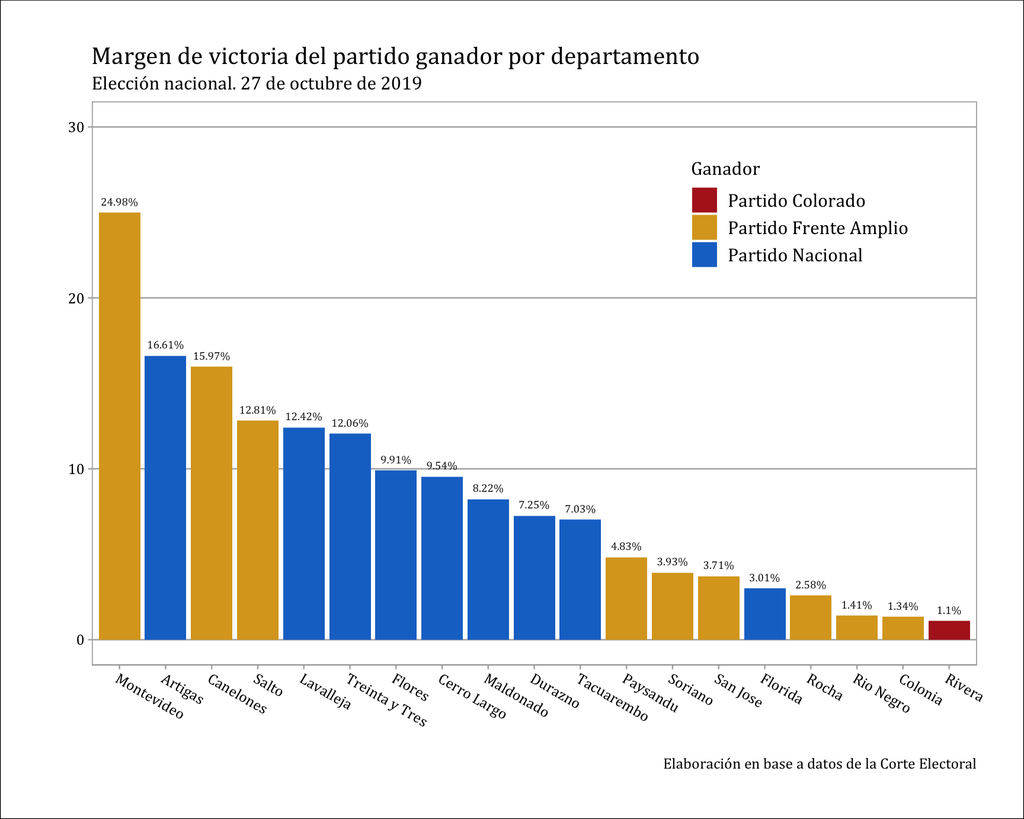

7. **Presente gráficamente (en un panel) un ajuste lineal de la votación por circuito de cada partido y la edad promedio de cada circuito de Montevideo**

[figure not shown]